# CRC Model CUP0006

Leyla Azarang and Renee Menezes

2024-04-11

```r
source("./scripts/mysplit.R")
source("./scripts/functions_data_centre.R")
```

## Read in data

First read in information about centers available for this model.

```r
xi <- 7
alldata <- readxl::read_excel("./data/overview1.xlsx")
myfile <- alldata$FileName[xi]
mymodel <- strsplit(myfile, split = " ")[[1]][ 1 ]
all.sheets <- as.character(alldata[xi, -1])
names(all.sheets) <- colnames(alldata)[ -1 ]
all.sheets <- all.sheets[ !is.na(all.sheets) ]
list.centers <- names(all.sheets)
```

The data here is for model CUP0006. It was analysed by the following centers:

```r
knitr::kable(list.centers, col.names = "Centers")
```

| Centers |
| --- |
| NKI |
| VHIO |
| IC |
| UNITO |
| KULEUVEN |

### Analysis per center

Reading the data per center.

```r
n_centers <- length(list.centers)

data_centers <- lapply(1:n_centers, read_sheet, myfile = myfile,
                       all.sheets = all.sheets)
names(data_centers) <- list.centers
```

The data is currently in the wide format, and for the analyses we need it in the long format (one observation per row, for one individual at a time).

```r
all_data_long <- lapply(1:n_centers, get_data_long, mydatac = data_centers)
names(all_data_long) <- list.centers
```

We now need to leave out measurements before the start of the treatment, and after ending it.

```r
data_long_treat <- lapply(1:n_centers, get_vol_treat, alldata = all_data_long)
names(data_long_treat) <- names(all_data_long)
```

## Exploratory data analysis

The following plots depict the tumor volume growth per each center, for each model separately.

```r
vp <- lapply(1:n_centers, function(xc){
p <-  ggplot(data = data_long_treat[[ xc ]], aes(x = days, y = volume,
                                             group = `GenealogyID`, color =Treatment)) +
    geom_line()+
    facet_wrap( vars( `GenealogyID`)  )+
    ylab("tumor volume")+
    theme(legend.position = "top") +
    ggtitle(paste(names(data_long_treat)[xc]) )
return(p)
}
)
```

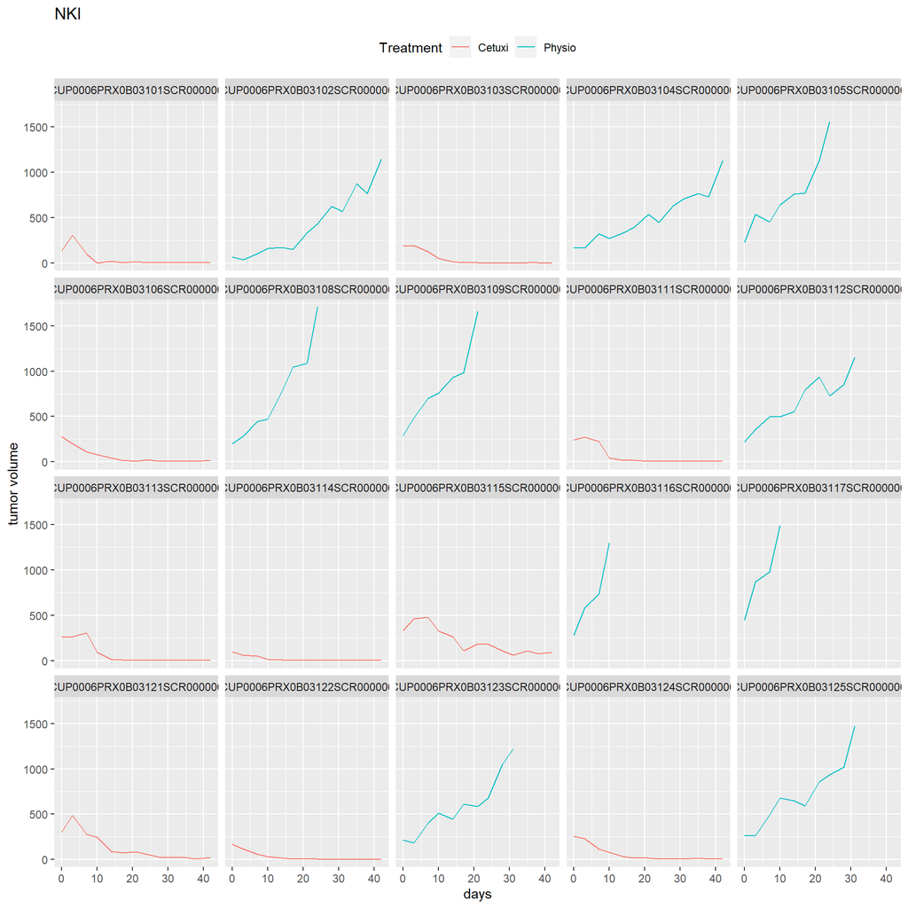

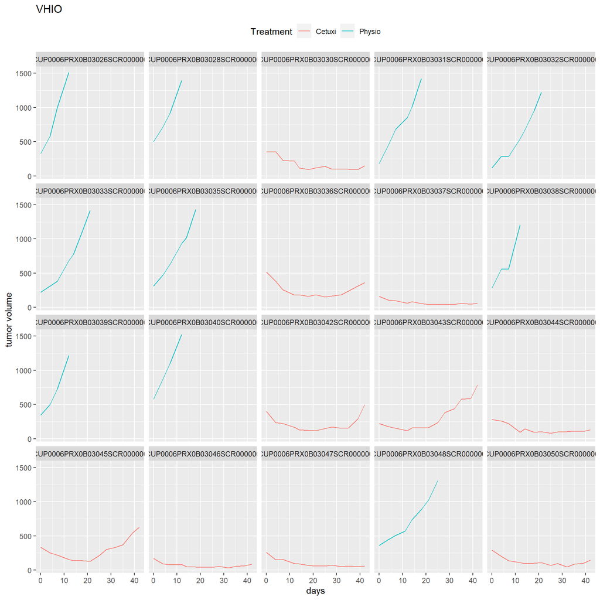

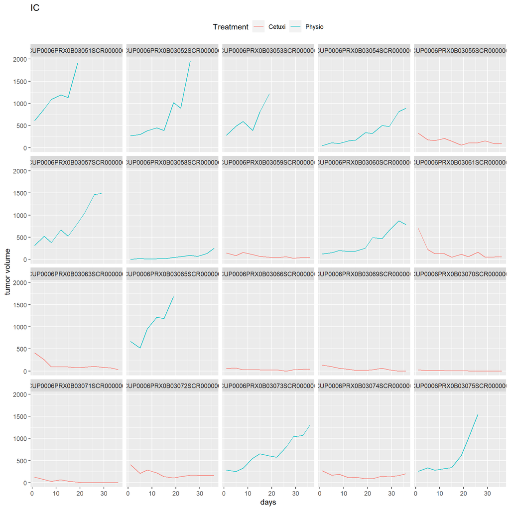

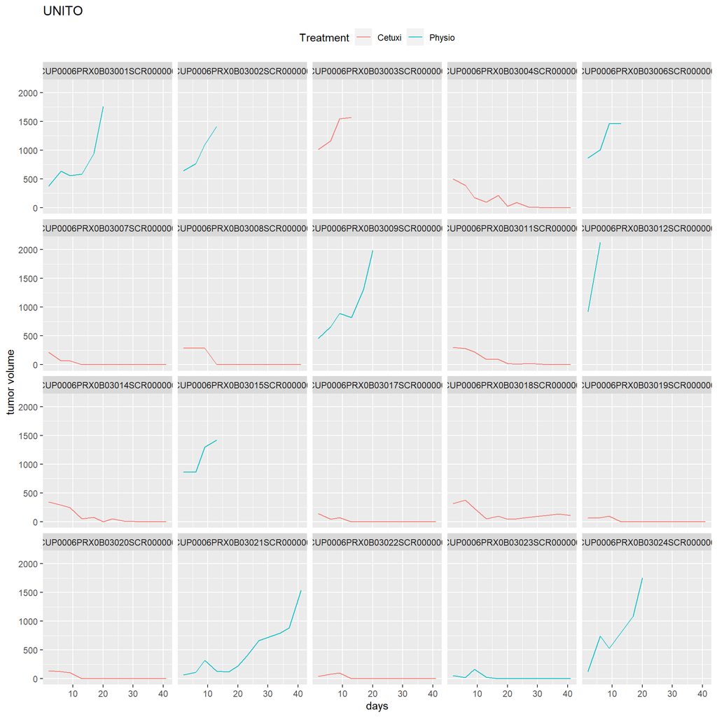

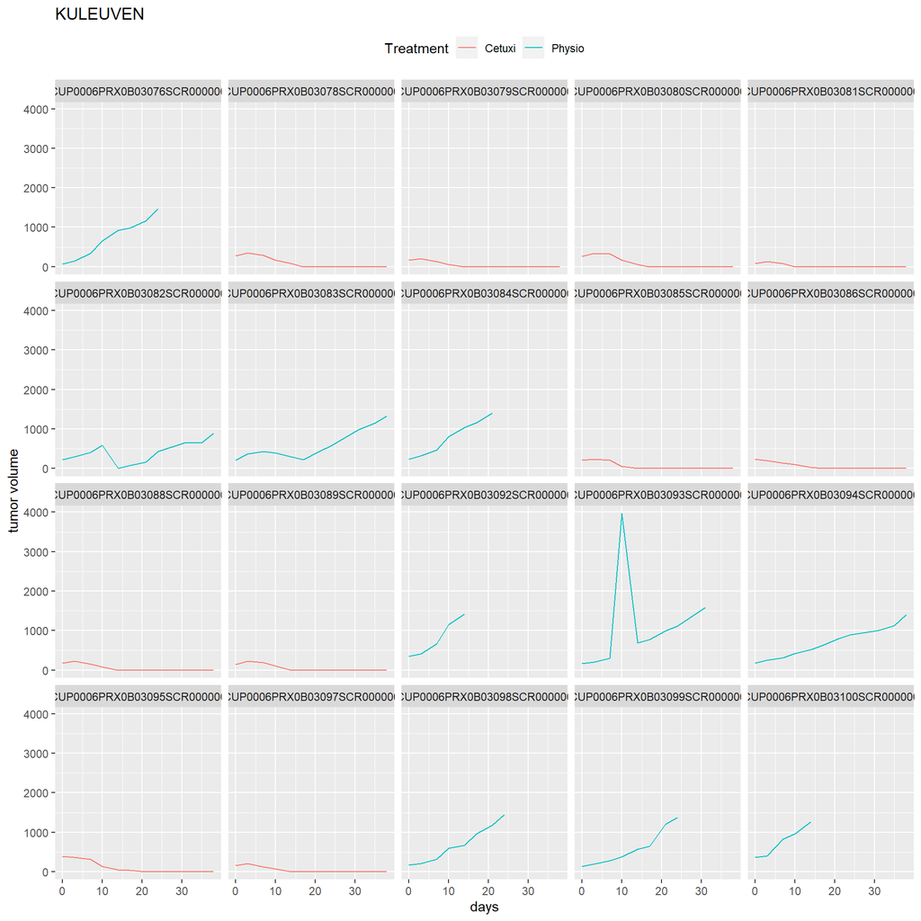

```r
vp
```

Now group all curves per treatment.

```r
vp <- lapply(1:n_centers, function(xc){
p <-  ggplot(data = data_long_treat[[ xc ]], aes(x = days, y = volume,
                                             group = GenealogyID, color = Treatment)) +
    geom_line()+
    facet_wrap( vars( `Treatment`)  )+
    ylab("tumor volume")+
    theme(legend.position = "top") +
    ggtitle(paste(names(data_long_treat)[xc]) )
return(p)
}
)
```

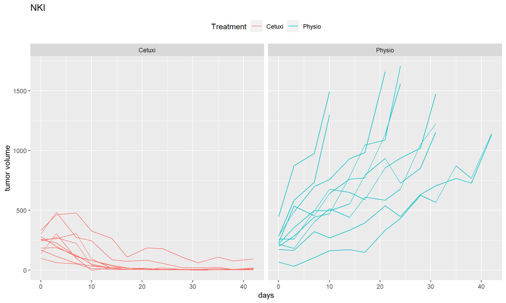

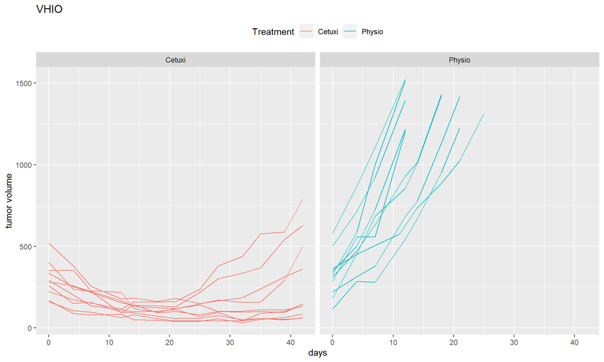

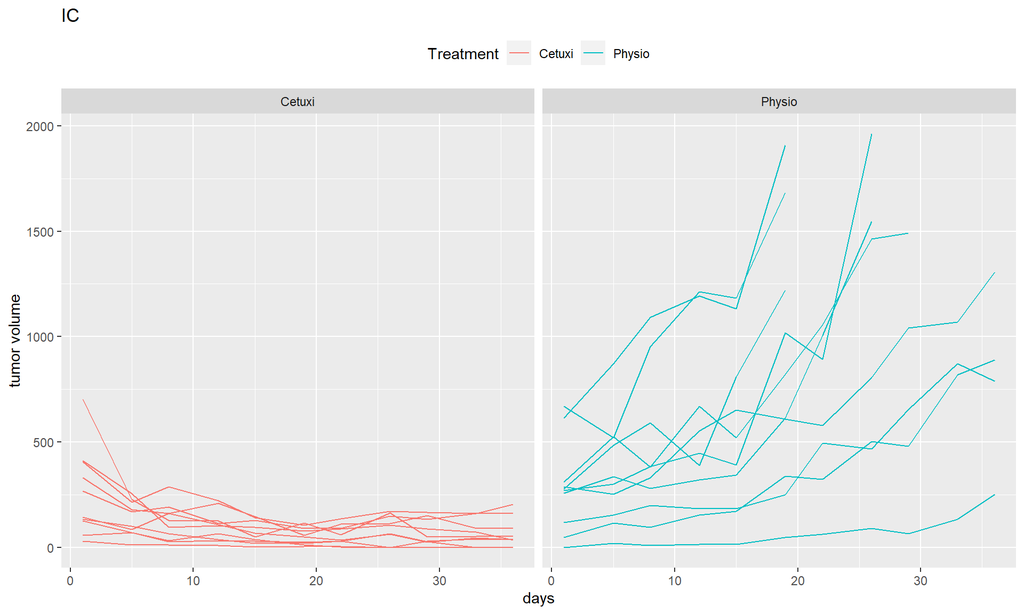

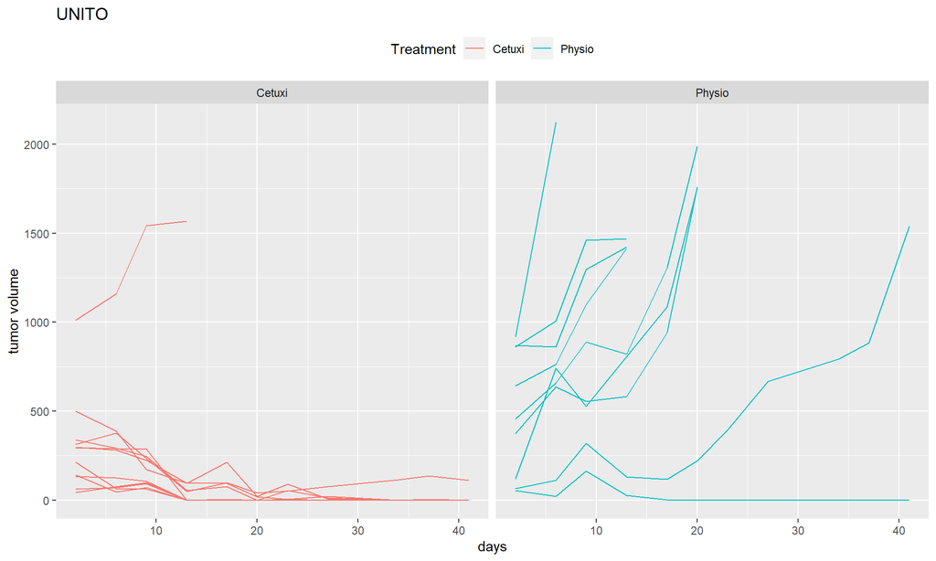

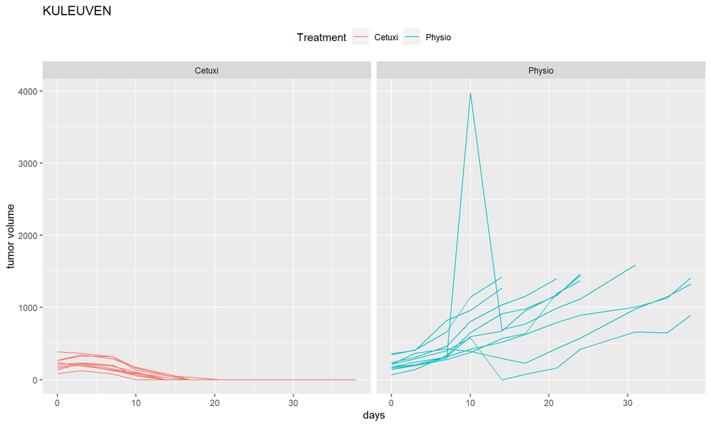

```r
vp
```

## The impact of center on tumor growth

In this section we investigate the effect of center on tumor growth in each treatment level. For this, we put all data together into a single data frame.

```r
all_data <- NULL
for(xc in 1:n_centers)
{
  datac <- data_long_treat[[ xc ]]
  datac$center <- rep(list.centers[ xc ], nrow(datac))
  all_data <- rbind(all_data, datac)
}
all_data <- all_data[!is.na(all_data$volume), ]
```

Now fit the mixed-effects model, with fixed effects for center, day and treatment.

```r
library(nlme)

lme_fit <- lme(volume ~  center + days  + days:center  + days:Treatment ,
               data = all_data, random = ~ days | GenealogyID)

summary(lme_fit)
```

```
## Linear mixed-effects model fit by REML
##   Data: all_data
##        AIC      BIC   logLik
##   12836.26 12909.07 -6403.13
##
## Random effects:
##  Formula: ~days | GenealogyID
##  Structure: General positive-definite, Log-Cholesky parametrization
##             StdDev    Corr
## (Intercept) 161.72533 (Intr)
## days         15.51572 0.811
## Residual    158.67042
##
## Fixed effects:  volume ~ center + days + days:center + days:Treatment
##                          Value Std.Error  DF   t-value p-value
## (Intercept)          149.50999  42.35011 853  3.530333  0.0004
## centerKULEUVEN        48.74882  59.22245  95  0.823148  0.4125
## centerNKI             51.41213  59.04750  95  0.870691  0.3861
## centerUNITO          144.70083  60.41332  95  2.395181  0.0186
## centerVHIO            80.12258  59.59634  95  1.344421  0.1820
## days                  -7.61611   3.91882 853 -1.943472  0.0523
## centerKULEUVEN:days    1.04892   5.19318 853  0.201980  0.8400
## centerNKI:days         1.22702   5.18677 853  0.236568  0.8130
## centerUNITO:days      11.58884   5.31362 853  2.180971  0.0295
## centerVHIO:days       13.74809   5.30348 853  2.592276  0.0097
## days:TreatmentPhysio  49.90470   2.98098 853 16.741061  0.0000
##  Correlation:
##                      (Intr) cnKULEUVEN cntNKI cnUNITO cnVHIO days   cKULEUVEN:
## centerKULEUVEN       -0.715
## centerNKI            -0.717  0.513
## centerUNITO          -0.700  0.501      0.503
## centerVHIO           -0.709  0.508      0.510  0.499
## days                  0.489 -0.342     -0.342 -0.329  -0.330
## centerKULEUVEN:days  -0.363  0.529      0.260  0.254   0.257 -0.666
## centerNKI:days       -0.363  0.259      0.537  0.254   0.257 -0.669  0.501
## centerUNITO:days     -0.356  0.253      0.254  0.479   0.249 -0.672  0.489
## centerVHIO:days      -0.357  0.254      0.254  0.247   0.498 -0.673  0.490
## days:TreatmentPhysio -0.026 -0.003     -0.006 -0.022  -0.034 -0.349  0.009
##                      cnNKI: cUNITO: cVHIO:
## centerKULEUVEN
## centerNKI
## centerUNITO
## centerVHIO
## days
## centerKULEUVEN:days
## centerNKI:days
## centerUNITO:days      0.491
## centerVHIO:days       0.491  0.483
## days:TreatmentPhysio  0.017  0.070   0.067
##
## Standardized Within-Group Residuals:
##         Min          Q1         Med          Q3         Max
## -2.61089439 -0.36683851 -0.05696042  0.30281715 19.70059739
##
## Number of Observations: 959
## Number of Groups: 100
```

```r
fitted <- fitted(lme_fit, level = 0)


all.equal(names(fitted), all_data$GenealogyID)
```

```
## [1] "Modes: character, numeric"
## [2] "Attributes: < target is NULL, current is list >"
## [3] "target is character, current is factor"
```

```r
fitted <- tibble( MouseID = names(fitted),   center = all_data$center,
                 Treatment = all_data$Treatment, days = all_data$days, fit_fix = fitted)
```

The following plot depicts the tumor volume increase in different centers for both treatment groups.

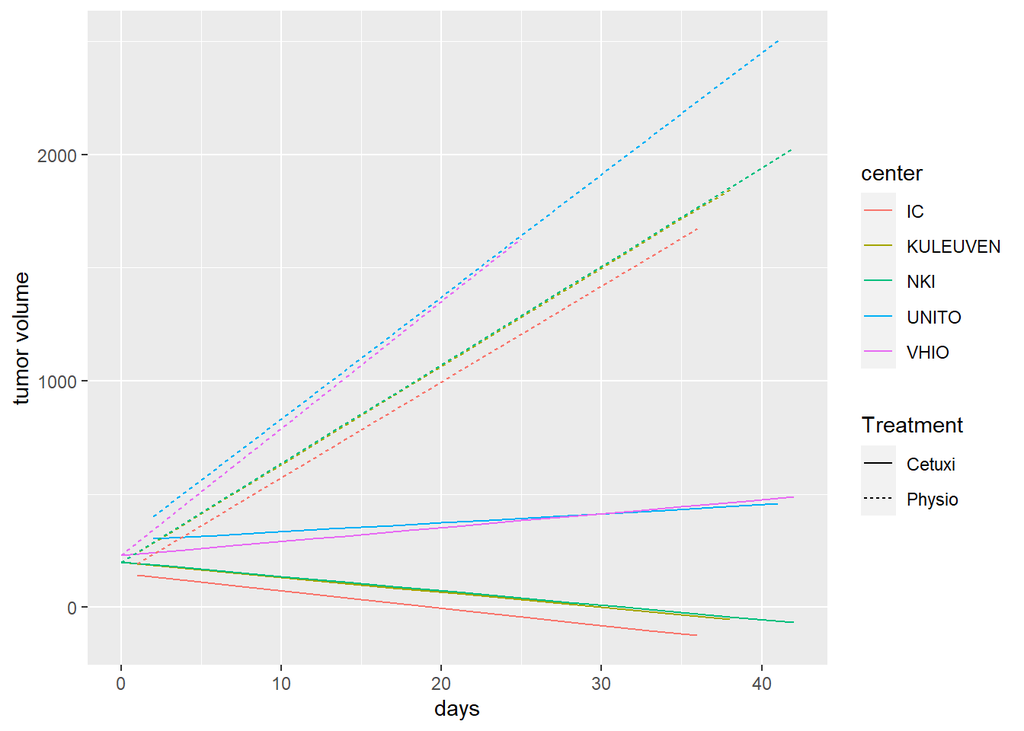

```r
ggplot(fitted, aes(x = days, y = fit_fix, color = center))+
  geom_line(aes(linetype=Treatment))+
  ylab("tumor volume")
```

## The effect of treatment per center

```r
cont <- nlmeControl( maxIter = 100000, msMaxIter = 1000, tolerance = 1e-6, niterEM = 10000, msMaxEval = 10000)

all_fits <- lapply(1:n_centers, function(xc){
      lme_fit <- lme(volume ~   days +  days:Treatment, data = data_long_treat[[xc]],
                     random = ~ days | GenealogyID, control = cont)
      mysumm <- summary(lme_fit)
      mfitted <- fitted(lme_fit, level =0)
      res_fitted <- tibble( GenealogyID = names(mfitted),
                           Treatment = data_long_treat[[ xc ]]$Treatment,
                            days = data_long_treat[[ xc ]]$days, fit_fix = mfitted)

      return(list( lme_fit= lme_fit , fit_sum = mysumm , fit_tibble = res_fitted  ) )
}
)

list_lme_fit <- lapply(1:n_centers , function(xc){return(all_fits[[xc]][[1]])})
names(list_lme_fit) <- names(data_long_treat)

list_lme_summ <- lapply(1:n_centers , function(xc){return(all_fits[[xc]][[2]])})
names(list_lme_summ) <- names(data_long_treat)

list_lme_fitted <- lapply(1:n_centers , function(xc){return(all_fits[[xc]][[3]])})
names(list_lme_fitted) <- names(data_long_treat)
```

```r
vp <- lapply(1:n_centers, function(xc){

p <- ggplot(data = list_lme_fitted[[xc]], aes(x = days, y = fit_fix))+
  geom_line(aes(color=Treatment))+
  ylab("tumor volume")+
  ggtitle(paste(names(data_long_treat)[xc]) )
return(p)
}
)
```

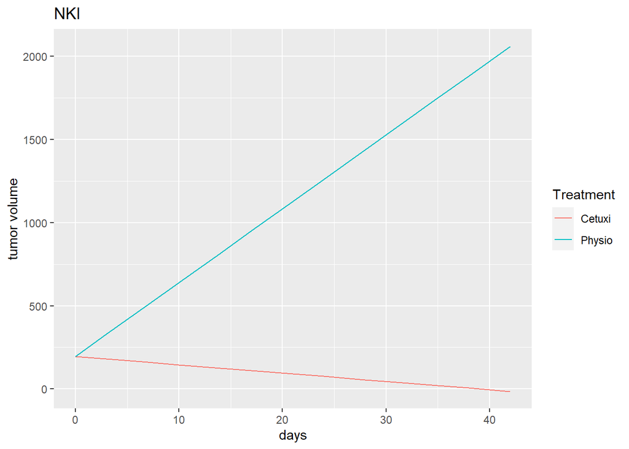

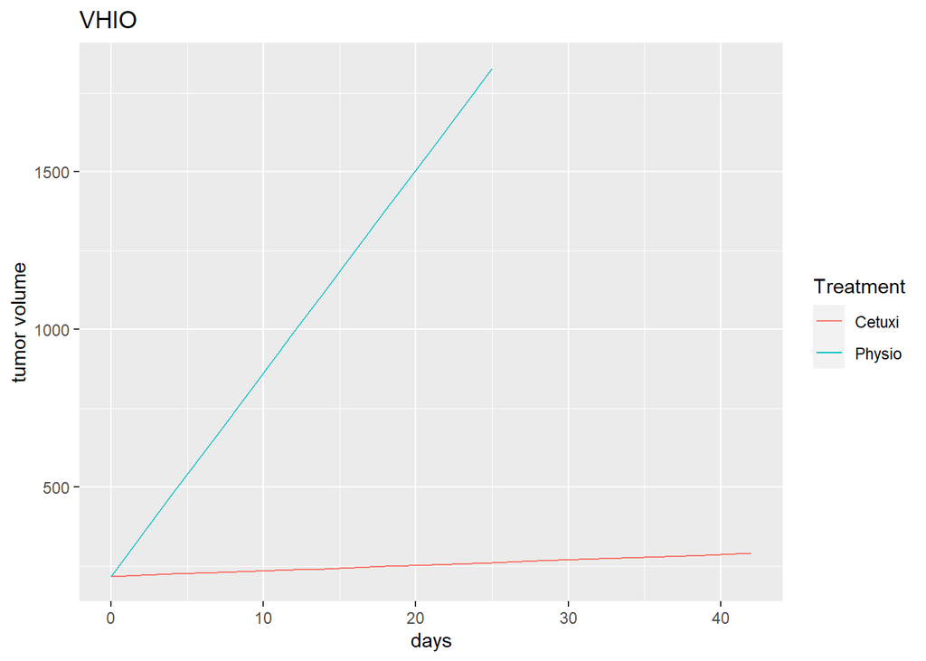

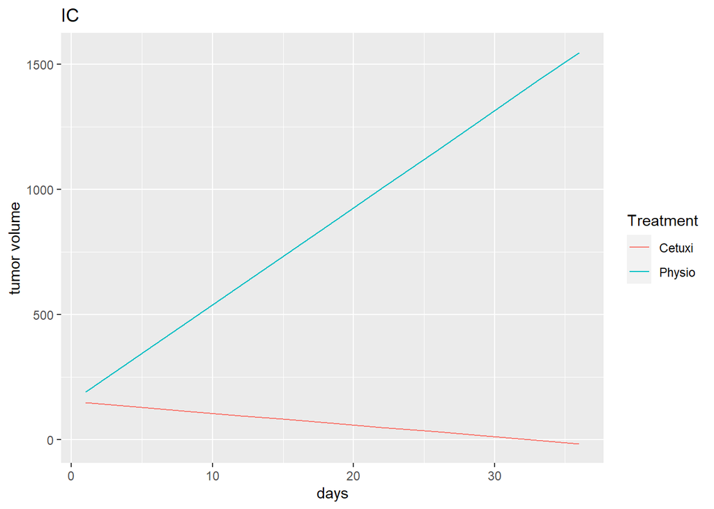

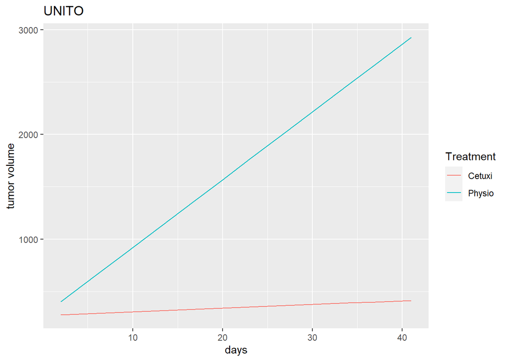

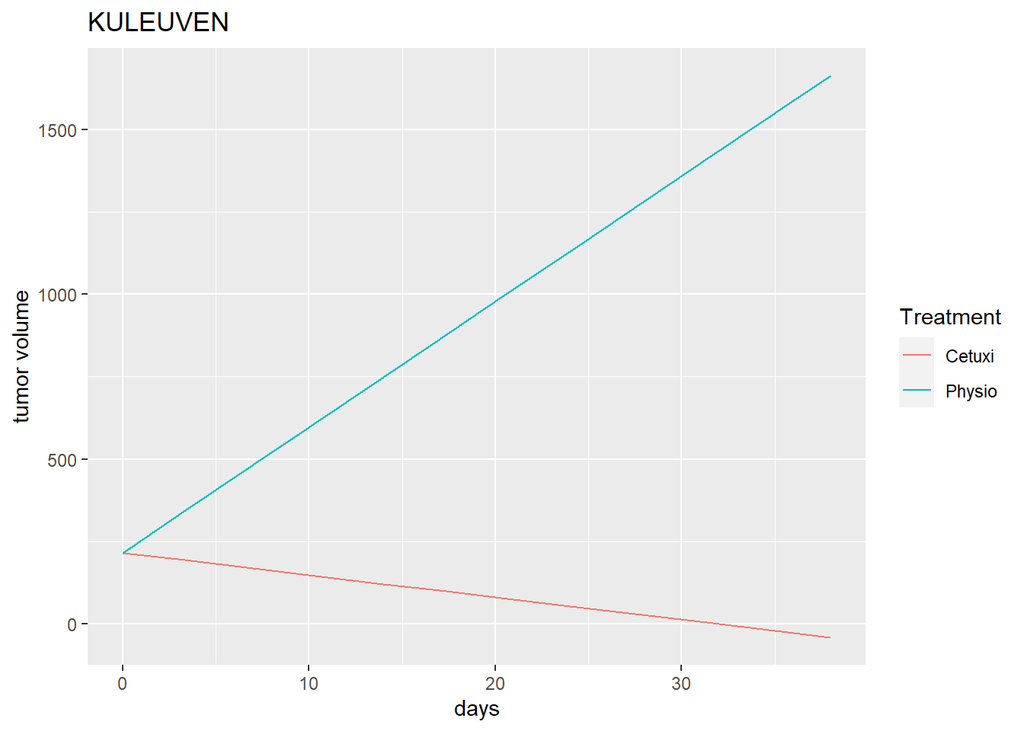

```r
vp
```

## Survival analysis

Below we make a list of survival data corresponding to different center.

```r
surv_data_centers <- lapply(1:n_centers , get_surv_data , mydatac = data_centers)
names(surv_data_centers) <- names(data_centers)
```

```r
tab_event_centers <- lapply(1:n_centers, function(xc){
  tab_event = table(surv_data_centers[[xc]]$`event/status/sensor`)

 return(tab_event)
}
)

names(tab_event_centers) <- names(data_centers)
```

```r
tab_event_centers
```

```
## $NKI
##
##  0  1
## 10 10
##
## $VHIO
##
##  0  1
## 10 10
##
## $IC
##
##  0  1
## 13  7
##
## $UNITO
##
##  0  1
## 11  9
##
## $KULEUVEN
##
##  0  1
## 11  9
```

```r
surv_object_centers <- lapply(1:n_centers , get_surv_object ,surv_data_centers)
names(surv_object_centers) <- names(data_centers)
```

```r
surv_fit_centers <- lapply(1:n_centers , get_surv_fit, surv_object_centers , surv_data_centers)
names(surv_fit_centers) <- names(data_centers)
```

From the following tables, for each center, we can see the number of events in each treatment group.

```r
surv_fit_centers
```

```
## $NKI
## Call: survfit(formula = surv_objectc[[xi]] ~ Treatment, data = surv_datac[[xi]])
##
##                   n events median 0.95LCL 0.95UCL
## Treatment=Cetuxi 10      0     NA      NA      NA
## Treatment=Physio 10     10   27.5      21      NA
##
## $VHIO
## Call: survfit(formula = surv_objectc[[xi]] ~ Treatment, data = surv_datac[[xi]])
##
##                   n events median 0.95LCL 0.95UCL
## Treatment=Cetuxi 10      0     NA      NA      NA
## Treatment=Physio 10     10     15      12      NA
##
## $IC
## Call: survfit(formula = surv_objectc[[xi]] ~ Treatment, data = surv_datac[[xi]])
##
##                   n events median 0.95LCL 0.95UCL
## Treatment=Cetuxi 10      0     NA      NA      NA
## Treatment=Physio 10      7   26.5      18      NA
##
## $UNITO
## Call: survfit(formula = surv_objectc[[xi]] ~ Treatment, data = surv_datac[[xi]])
##
##                   n events median 0.95LCL 0.95UCL
## Treatment=Cetuxi 11      1     NA      NA      NA
## Treatment=Physio  9      8     21      14      NA
##
## $KULEUVEN
## Call: survfit(formula = surv_objectc[[xi]] ~ Treatment, data = surv_datac[[xi]])
##
##                   n events median 0.95LCL 0.95UCL
## Treatment=Cetuxi 10      0     NA      NA      NA
## Treatment=Physio 10      9     24      21      NA
```

### The effect of treatment on survival time

The following plots depict the survival curves in each center.

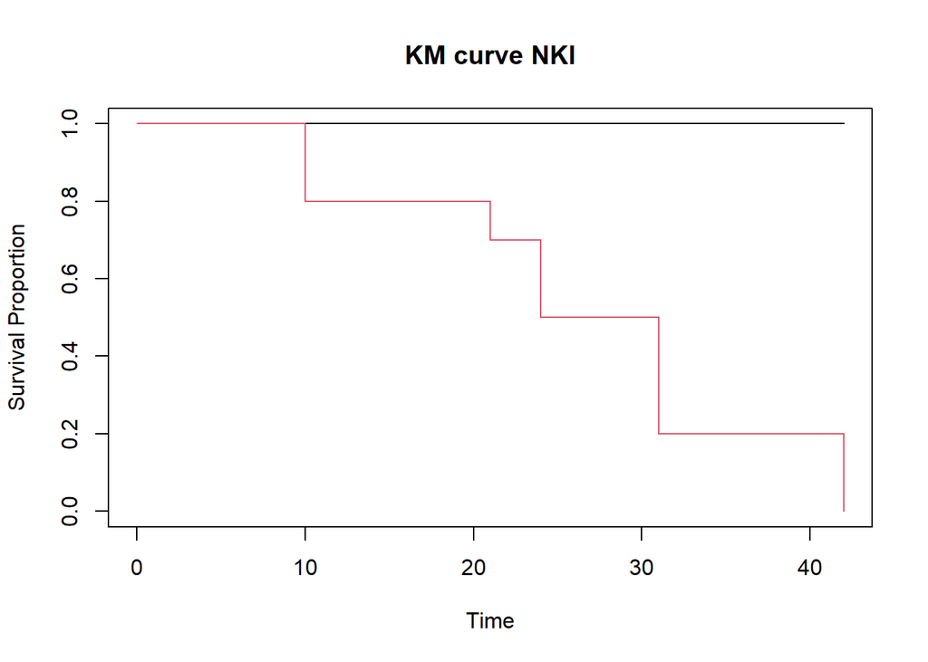

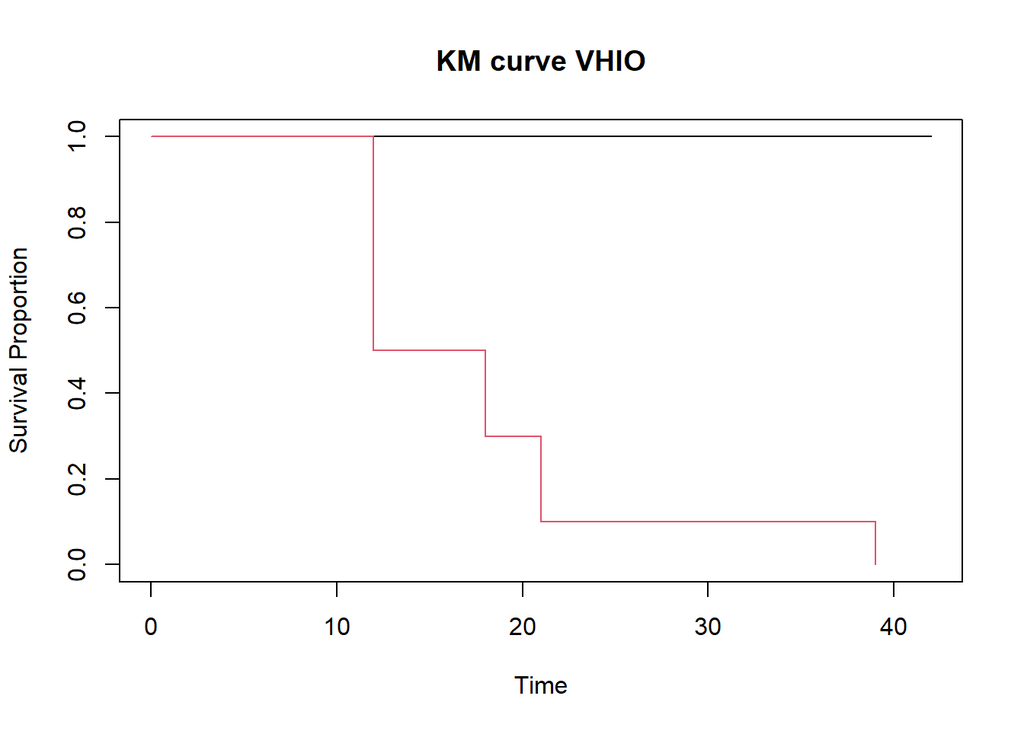

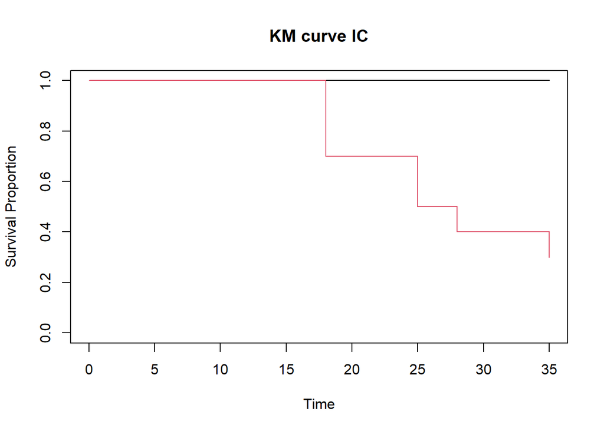

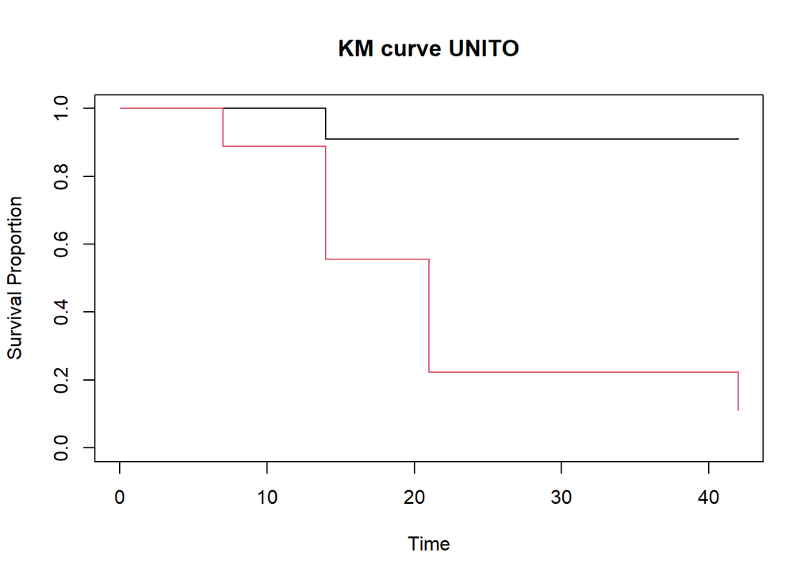

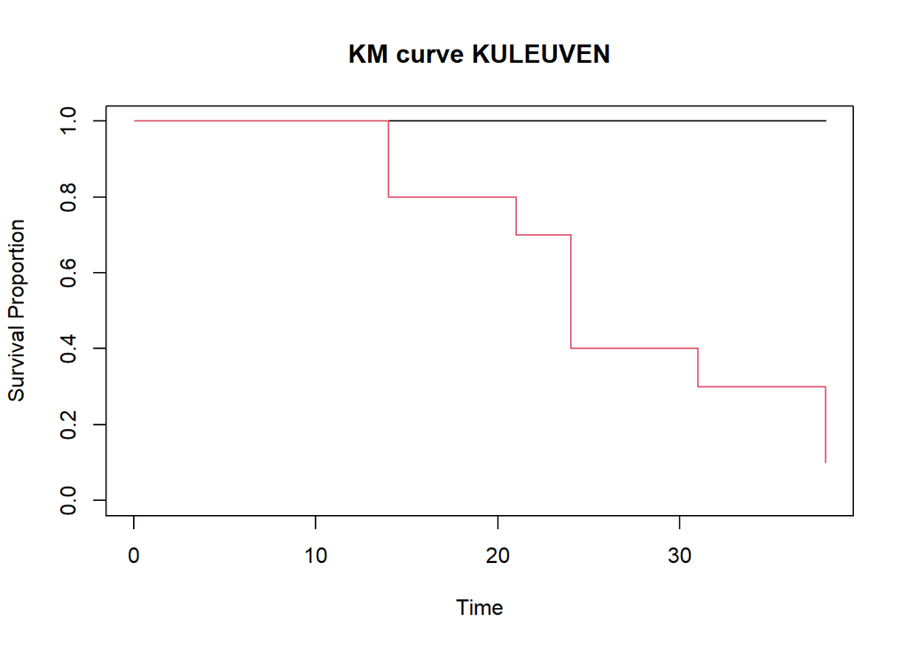

[output not shown]

```r
lapply( 1:n_centers, function(xc){
  plot(surv_fit_centers[[xc]],
     ylab = "Survival Proportion",
     xlab = "Time",
     col = c(1,2),
     main = paste("KM curve",names(data_centers)[xc]))
    }
)
```

```r
cox_centers <- lapply(1:n_centers, function(xc){
    cox <- coxph(surv_object_centers[[xc]] ~ 1 , data = surv_data_centers[[xc]])
    return(cox)
}
)
names(cox_centers)<- names(data_centers)
```

## Joint modelling

In this section, we use both survival and tumor growth altogether to analyse the data. In this part, for each center, we investigate the effect of the treatment on tumor growth by using the the association of tumor growth with survival time.

```r
jointFit_centers <- lapply(1:n_centers, function(xc){
    jointFit <- jm(cox_centers[[xc]], list_lme_fit[[xc]], time_var = "days", data_Surv = surv_data_centers[[xc]] ,  n_iter = 85000L, n_burnin = 3500L)
    sum <- summary(jointFit)
    return(sum)
}
)
```

```r
pvals <- round(sapply(1:n_centers, function(xc)jointFit_centers[[xc]]$Outcome1[["days:TreatmentPhysio", "P"]]), 3)
names(jointFit_centers) <- names(data_centers)
jointFit_centers
```

```
## $NKI
##
## Call:
## jm(Surv_object = cox_centers[[xc]], Mixed_objects = list_lme_fit[[xc]],
##     time_var = "days", data_Surv = surv_data_centers[[xc]], n_iter = 85000L,
##     n_burnin = 3500L)
##
## Data Descriptives:
## Number of Groups: 20     Number of events: 10 (50%)
## Number of Observations:
##   volume: 217
##
##                  DIC        WAIC        LPML
## marginal    3708.624 6562485.001 -964120.631
## conditional 3085.212    3079.383   -1561.497
##
## Random-effects covariance matrix:
##
##        StdDev     Corr
## (Intr) 125.7939 (Intr)
## days   17.1677  0.4439
##
## Survival Outcome:
##                 Mean  StDev   2.5%  97.5% P   Rhat
## value(volume) 0.0089 0.0018 0.0056 0.0125 0 1.0345
##
## Longitudinal Outcome: volume (family = gaussian, link = identity)
##                          Mean   StDev     2.5%    97.5%      P   Rhat
## (Intercept)          194.9149 21.7332 152.6088 237.9944 0.0000 1.0000
## days                  -5.1162  4.9700 -14.9541   4.7487 0.2895 1.0001
## days:TreatmentPhysio  50.6517  7.1241  37.0743  65.2903 0.0000 1.0004
## sigma                 93.4178  4.9757  84.3263 103.8343 0.0000 1.0001
##
## MCMC summary:
## chains: 3
## iterations per chain: 85000
## burn-in per chain: 3500
## thinning: 1
## time: 1.4 min
##
```

[output cut: 144 more lines]

```
## value(volume) 0.0063 0.0019 0.003 0.0105 0 1.0476
##
## Longitudinal Outcome: volume (family = gaussian, link = identity)
##                          Mean   StDev     2.5%    97.5%      P   Rhat
## (Intercept)          211.3598 24.7365 162.8732 259.6477 0.0000 1.0008
## days                  -6.9960  3.6099 -14.1100   0.1871 0.0553 1.0001
## days:TreatmentPhysio  47.9753  5.6500  37.3600  59.6948 0.0000 1.0004
## sigma                277.2204 15.1128 249.4904 308.7908 0.0000 1.0001
##
## MCMC summary:
## chains: 3
## iterations per chain: 85000
## burn-in per chain: 3500
## thinning: 1
## time: 1.4 min
```

```r
# plot joint models
Name_Treat <- levels(factor(unique(data_long_treat[[5]]$Treatment)))
list_data_JMfit <- lapply(1:n_centers , function(xc){
  fit <- jointFit_centers[[xc]]$Outcome1
 a <- fit[1,"Mean"]
 b_Cont <- fit["days","Mean"]
 b_Treat <- b_Cont + fit[3,"Mean"]

 days <- 0:max(0:max(data_long_treat[[xc]]$days))
 pred_Cont <- a + b_Cont *days
 pred_Treat <- a + b_Treat *days
 Group <- rep(names(data_long_treat)[xc], length(days))
 data_JMfit <- tibble(day = days, pred_Cont= pred_Cont,       pred_Treat= pred_Treat, Group= Group)

 data_JMfit <- data_JMfit %>%
  gather(key= "Treatment", value="Pred", -day,  -Group ) %>%
  mutate(Pred = as.numeric(Pred))%>%
  mutate(Treatment =factor( ifelse(Treatment =="pred_Cont", Name_Treat[1], Name_Treat[2])))
 return(data_JMfit)
}
)

names(list_data_JMfit) <- names(data_centers)
```

```r
JMp <- lapply(1:n_centers, function(xc){

p <- ggplot(data =list_data_JMfit[[xc]], aes(x = day, y = Pred, color = Treatment))+
   geom_line()+
   geom_hline( yintercept = 1500, color="#331112", linetype="longdash")+
   ylab("tumor volume")+
   scale_x_continuous( breaks=seq(0,45,5)) +
  scale_y_continuous(lim=c(0,2000),breaks=seq(0,2000,500))+
 ggtitle(paste(names(list_data_JMfit)[xc]) )+
     annotate("text", x = 5, y = 100, label = paste("p-value:", pvals[[xc]]) )
return(p)
}
)
```

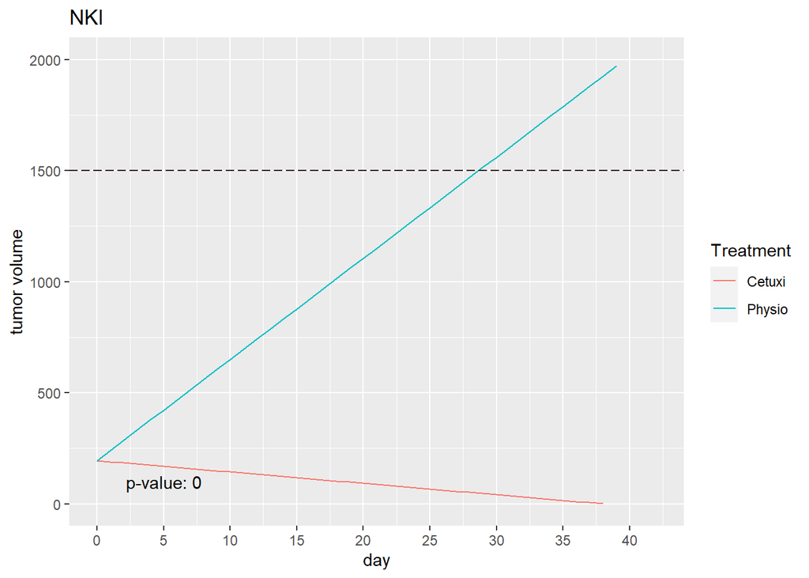

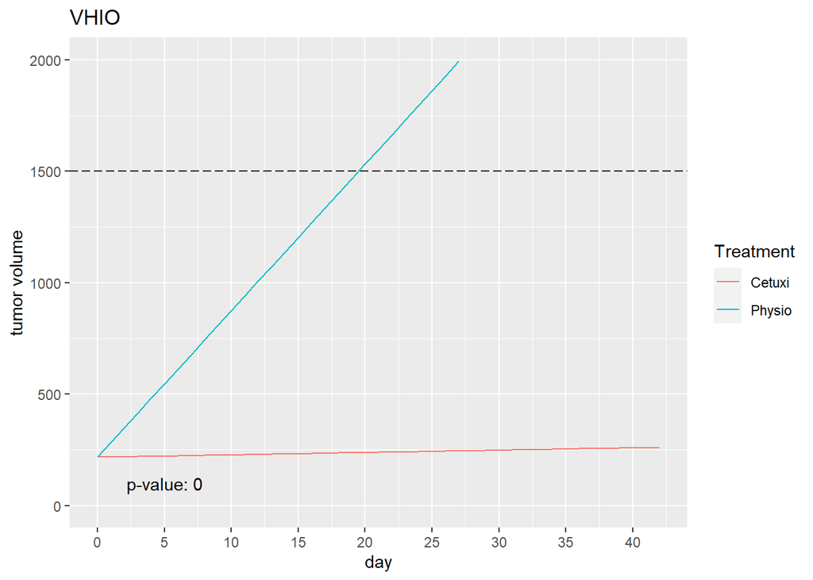

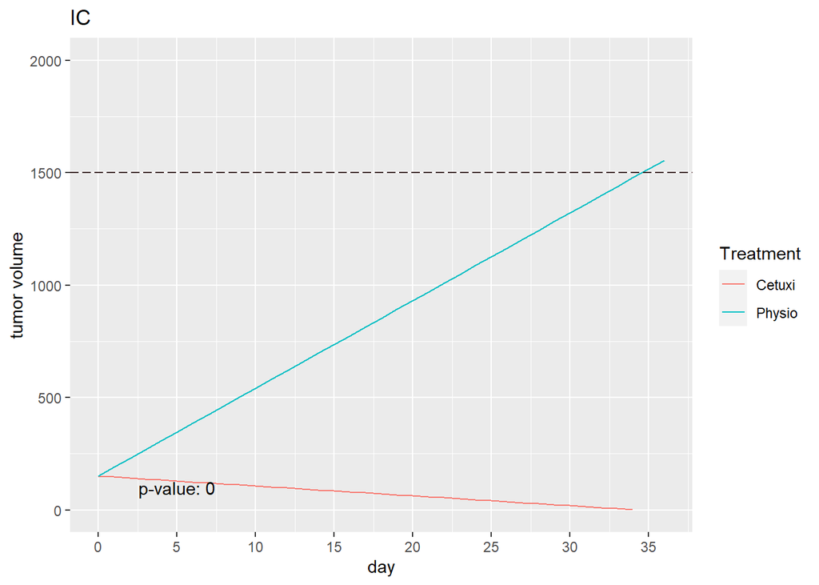

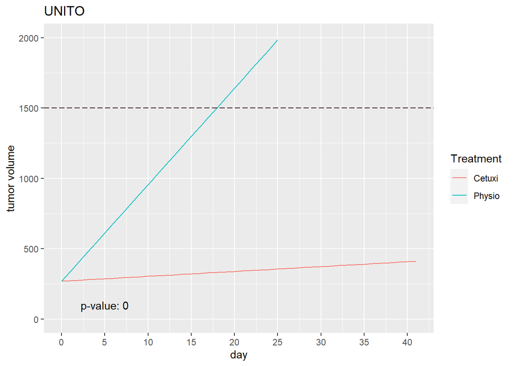

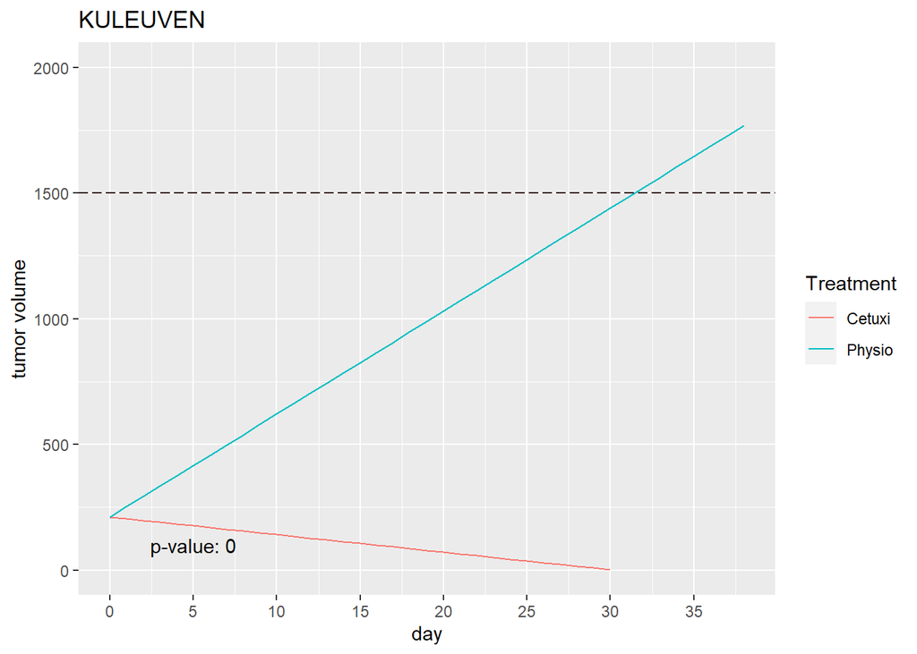

```r
JMp
```

## Conclusion

By taking both survival information and tumor volume data into consideration, we observe that in all centers there is a significant effect of treatment on tumor volume growth. Treatment significantly controls tumor growth.